# RI Bisection Analysis

Carter Daniels

2023-07-23

```r
rm(list=ls())
#import libraries
library(tidyverse)
library(lme4)
library(rstan)
library(shinystan)
options(mc.cores = parallel::detectCores())
rstan_options(auto_write = TRUE)
```

```r
#datapath and functions

data.path <- "D:\\Dropbox Drive Folder\\Dropbox\\2 All of Carter's Stuff\\Carter Local\\Dissertation Stuffs\\RI Bisection\\"
```

```r
#notes for translating trial-by-trial matrices:
#cols:
##1: trial-type; #2: LTI; #3: interval; #4: response; #5 choice latency/or retrieval latency?
##1: 210: Nose-poke; 310: External
##2: 210: animal generated; 310: programed at 2.5 s
##3: interval
##4: 140: short; 150: long
##5: animal generated

tbt_matrices <- readxl::read_excel(paste0(data.path,"Summary.xlsx"),
                                   sheet="TbT Arrays")
sub_names <- rep(c("InitiationType","LTI","Interval","Choice","ChoiceLat"),8)
all_names <- c("Session","Trial",sub_names)
colnames(tbt_matrices)<-all_names
tbt_matrices_reform <- NULL
end = 2
for (ea_subj in 1:8)
{
  start = end+1
  end = end+5
  tbt_matrices_reform <- rbind(tbt_matrices_reform,
                               tbt_matrices[,c(1,2,start:end)])

}
tbt_matrices_reform$subjID <- rep(c(1:8),ea=nrow(tbt_matrices))
tbt_matrices_reform <- tbt_matrices_reform[complete.cases(tbt_matrices_reform),]

tbt_matrices_reform$InitiationType[tbt_matrices_reform$InitiationType==310]<-0
tbt_matrices_reform$InitiationType[tbt_matrices_reform$InitiationType==210]<-1
tbt_matrices_reform$Choice[tbt_matrices_reform$Choice==140]<-0
tbt_matrices_reform$Choice[tbt_matrices_reform$Choice==150]<-1


###restrict sessions
#note still need to modify some given box issues
avail_sessions <- c(40:43,45:48,93:96,98:101,127:130,135,133:138)
tbt_matrices_reform <- tbt_matrices_reform[tbt_matrices_reform$Session %in%
                                             avail_sessions,]

###interval condition defined by Long FI
tbt_matrices_reform$IntervalCond <- "A12"
tbt_matrices_reform$IntervalCond[tbt_matrices_reform$Session %in%
                                   c(93:101)] <- "A18"
tbt_matrices_reform$IntervalCond[tbt_matrices_reform$Session %in%
                                   c(127:138)] <- "B12"


#set min interval to zero
tbt_matrices_reform$ogInterval <- tbt_matrices_reform$Interval

tbt_matrices_reform$Interval[tbt_matrices_reform$IntervalCond == "A12"] <-
  tbt_matrices_reform$Interval[tbt_matrices_reform$IntervalCond == "A12"] -
  min(tbt_matrices_reform$Interval[tbt_matrices_reform$IntervalCond == "A12"])

tbt_matrices_reform$Interval[tbt_matrices_reform$IntervalCond == "A18"] <-
  tbt_matrices_reform$Interval[tbt_matrices_reform$IntervalCond == "A18"] -
  min(tbt_matrices_reform$Interval[tbt_matrices_reform$IntervalCond == "A18"])

tbt_matrices_reform$Interval[tbt_matrices_reform$IntervalCond == "B12"] <-
  tbt_matrices_reform$Interval[tbt_matrices_reform$IntervalCond == "B12"] -
  min(tbt_matrices_reform$Interval[tbt_matrices_reform$IntervalCond == "B12"])


### add session information (baseline, PF)
baseline_sess <- c(40,41,45,46,93,94,98,99,127,128,133,134)
pf24hr <- c(43,48,96,101,130,136)
pf1hr <- pf24hr-1


tbt_matrices_reform$Condition <- "Extinction"
tbt_matrices_reform$Condition[tbt_matrices_reform$Session %in%
                                baseline_sess] <- "Baseline"
tbt_matrices_reform$Condition[tbt_matrices_reform$Session %in%
                                pf24hr] <- "Pre-feeding 24hr"
tbt_matrices_reform$Condition[tbt_matrices_reform$Session %in%
                                pf1hr] <- "Pre-feeding 1hr"


#data with technical errors/box malfunctions to be substiuted with reruns for dropped

#subj 4 gets dropped here because only completed 13 trials due to lever problem,
#missing 24 hr pre-feeding from B12 condition
# tbt_matrices_reform$Condition[which(tbt_matrices_reform$subjID==4 &
#                                           tbt_matrices_reform$Session==96)]<-"DROP"

#onset of test for subjects 1 and 2 delayed due to lever problems
#only one baseline session prior to manipulation due to box issues
tbt_matrices_reform$Condition[which(
  tbt_matrices_reform$subjID %in% c(1,2) &
    tbt_matrices_reform$Session==136)] <- c("Baseline")
tbt_matrices_reform$Condition[which(
  tbt_matrices_reform$subjID %in% c(1,2) &
    tbt_matrices_reform$Session==137)] <- c("Pre-feeding 1hr")
tbt_matrices_reform$Condition[which(
  tbt_matrices_reform$subjID %in% c(1,2) &
    tbt_matrices_reform$Session==138)] <- c("Pre-feeding 24hr")


tbt_matrices_reform$Condition[which(
  tbt_matrices_reform$subjID %in% c(1,2) &
    tbt_matrices_reform$Session >= 133 &
    tbt_matrices_reform$Session <= 135)] <-  "DROP"

#this is to ignore levels of pre-feeding
tbt_matrices_reform$AltCondition <- 0
tbt_matrices_reform$AltCondition[grepl("Pre-feeding",
                                       tbt_matrices_reform$Condition)] <- 1

#check conditions for each animal

subj_conditions <- unique(tbt_matrices_reform[,c("subjID","InitiationType","IntervalCond","Condition", "Session")])
subj_conditions <- pivot_wider(subj_conditions, names_from = Condition ,values_from=IntervalCond)

subj_conditions
```

```
## # A tibble: 199 × 8
##    subjID InitiationType Session Baseline `Pre-feeding 1hr` `Pre-feeding 24hr`
##     <int>          <dbl>   <dbl> <chr>    <chr>             <chr>
##  1      1              0      40 A12      <NA>              <NA>
##  2      1              0      41 A12      <NA>              <NA>
##  3      1              0      42 <NA>     A12               <NA>
##  4      1              0      43 <NA>     <NA>              A12
##  5      1              1      45 A12      <NA>              <NA>
##  6      1              1      46 A12      <NA>              <NA>
##  7      1              1      47 <NA>     A12               <NA>
##  8      1              1      48 <NA>     <NA>              A12
##  9      1              1      93 A18      <NA>              <NA>
## 10      1              1      94 A18      <NA>              <NA>
## # ℹ 189 more rows
## # ℹ 2 more variables: DROP <chr>, Extinction <chr>
```

```r
#drops extinction condition
tbt_matrices_reform <- tbt_matrices_reform[tbt_matrices_reform$Condition!="DROP",]

tbt_matrices_reform <- tbt_matrices_reform[which(tbt_matrices_reform$Condition!="Extinction" &
                                                   tbt_matrices_reform$Session < 140),]
```

# 1. First Analysis: Logistic Regression

After formatting our data, we can now begin the analysis. Here we start with a simple glmer model using logistic regression. If this model fits well we can calculate the PSE and difference limen from the model and use them as proxies for the median and IQR calculated empirically from the switch-timing task.

```r
#glm logistic model

logistic_test <- glmer(Choice ~
                         IntervalCond*Interval*AltCondition*InitiationType +
                         (1+Interval|subjID),
                       data =tbt_matrices_reform,
                       family=binomial(link="logit"),
                       nAGQ = 0,
                       control=glmerControl(optimizer="bobyqa",
                                            optCtrl=list(maxfun=2e5)))
tbt_matrices_reform$predicted_response <- predict(logistic_test,
                                                  type="response")

summary_outcome <- summary(logistic_test)

avg_pfs <- tbt_matrices_reform %>%
  group_by(AltCondition,IntervalCond,Interval,InitiationType) %>%
  summarise(across(.cols=c(Choice,predicted_response),.fns=c(mean,sd)))
```

```
## You can override using the `.groups` argument.
```

```r
subj_avg_pfs <- tbt_matrices_reform %>%
  group_by(subjID,AltCondition,IntervalCond,Interval,InitiationType) %>%
  summarise(across(.cols=c(Choice,predicted_response),.fns=c(mean,sd)))
```

```
## 'Interval'. You can override using the `.groups` argument.
```

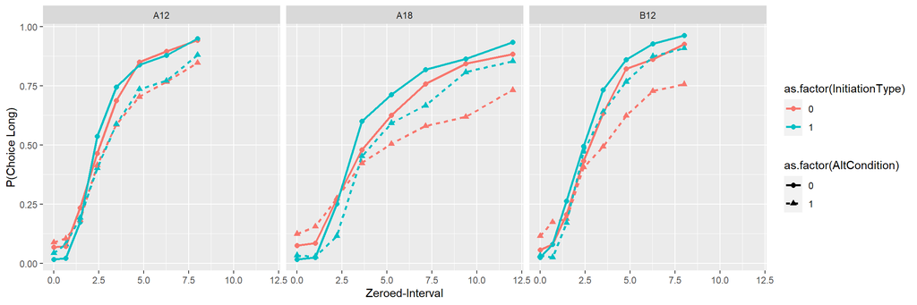

```r
ggplot()+
  geom_point(data=avg_pfs,
             aes(x=Interval,y=Choice_1,color=as.factor(InitiationType),
                 shape = as.factor(AltCondition)),
             size = 2) +
  geom_line(data=avg_pfs,
             aes(x=Interval,y=Choice_1,
                 color=as.factor(InitiationType),
                 linetype = as.factor(AltCondition)),
            size = 1)+
  xlab("Zeroed-Interval") +
  ylab("P(Choice Long)")+
  facet_wrap(~IntervalCond)
```

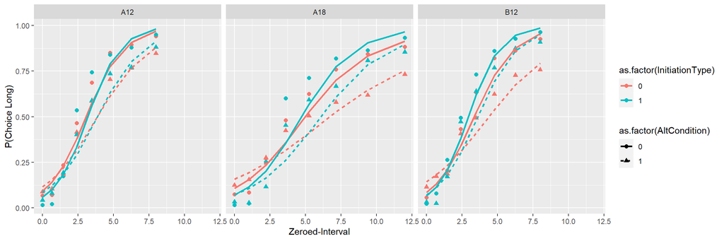

```r
ggplot()+
  geom_point(data=avg_pfs,
             aes(x=Interval,y=Choice_1,color=as.factor(InitiationType),
                 shape = as.factor(AltCondition)),
             size = 2) +
  geom_line(data=avg_pfs,
             aes(x=Interval,y=predicted_response_1,
                 color=as.factor(InitiationType),
                 linetype = as.factor(AltCondition)),
            size = 1) +
  xlab("Zeroed-Interval") +
  ylab("P(Choice Long)")+
  facet_wrap(~IntervalCond)
```

The fits of the model are decent, but its fairly clear the model has an issue accounting for the steepness of the rise across intervals. We can fix this by implementing a different model. Before doing so, let’s see what this model suggests about the data

```r
summary_outcome
```

```
## Generalized linear mixed model fit by maximum likelihood (Adaptive
##   Gauss-Hermite Quadrature, nAGQ = 0) [glmerMod]
##  Family: binomial  ( logit )
## Formula: Choice ~ IntervalCond * Interval * AltCondition * InitiationType +
##     (1 + Interval | subjID)
##    Data: tbt_matrices_reform
## Control: glmerControl(optimizer = "bobyqa", optCtrl = list(maxfun = 2e+05))
##
##      AIC      BIC   logLik deviance df.resid
##  42884.3  43125.5 -21415.1  42830.3    56026
##
## Scaled residuals:
##      Min       1Q   Median       3Q      Max
## -17.4230  -0.3945  -0.2320   0.3560   4.7572
##
## Random effects:
##  Groups Name        Variance Std.Dev. Corr
##  subjID (Intercept) 0.07385  0.2718
##         Interval    0.01511  0.1229   -0.79
## Number of obs: 56053, groups:  subjID, 8
##
## Fixed effects:
##                                                      Estimate Std. Error
## (Intercept)                                          -2.30008    0.11045
## IntervalCondA18                                       0.17857    0.07982
## IntervalCondB12                                      -0.08007    0.07763
## Interval                                              0.74160    0.04600
## AltCondition                                          0.29876    0.07815
## InitiationType                                       -0.45325    0.08733
## IntervalCondA18:Interval                             -0.32015    0.01768
## IntervalCondB12:Interval                             -0.03127    0.02051
## IntervalCondA18:AltCondition                          0.20286    0.11337
## IntervalCondB12:AltCondition                          0.31383    0.11129
## Interval:AltCondition                                -0.24011    0.01931
## IntervalCondA18:InitiationType                        0.03137    0.13644
## IntervalCondB12:InitiationType                        0.20586    0.13354
## Interval:InitiationType                               0.11063    0.02430
## AltCondition:InitiationType                           0.13512    0.13506
## IntervalCondA18:Interval:AltCondition                 0.03106    0.02293
## IntervalCondB12:Interval:AltCondition                -0.09848    0.02646
```

[output cut: 19 more lines]

```
## IntervalCondA18:InitiationType                         0.230 0.818143
## IntervalCondB12:InitiationType                         1.542 0.123167
## Interval:InitiationType                                4.552 5.32e-06 ***
## AltCondition:InitiationType                            1.000 0.317090
## IntervalCondA18:Interval:AltCondition                  1.354 0.175617
## IntervalCondB12:Interval:AltCondition                 -3.722 0.000197 ***
## IntervalCondA18:Interval:InitiationType               -0.333 0.738760
## IntervalCondB12:Interval:InitiationType                1.955 0.050556 .
## IntervalCondA18:AltCondition:InitiationType           -2.555 0.010617 *
## IntervalCondB12:AltCondition:InitiationType           -2.625 0.008659 **
## Interval:AltCondition:InitiationType                  -1.166 0.243524
## IntervalCondA18:Interval:AltCondition:InitiationType   2.006 0.044885 *
## IntervalCondB12:Interval:AltCondition:InitiationType   2.582 0.009829 **
## ---
## Signif. codes:  0 '***' 0.001 '**' 0.01 '*' 0.05 '.' 0.1 ' ' 1
```

```
##
## Correlation matrix not shown by default, as p = 24 > 12.
## Use print(x, correlation=TRUE)  or
##     vcov(x)        if you need it
```

Given how the model was formulated, the intercept is the log odds of responding “Long” at the shortest interval under Baseline conditions in A12 in EI.

We want to know (1) does NP improve the log odds to respond long as intervals increase and (2) whether NP protects the log odds to respond long when we switch from Baseline conditions to Pre-feeding conditions.

**Does NP enhance this effect relative to EI?** Yes. We see that NP enhances the effect of interval relative to EI in A12, which does not appear to significantly differ in A18 or B12 (A12: Z = 4.55, p < .001; A18: Z = -0.33 p = 0.74; B12: Z=1.96, p = 0.05).

**Does Pre-feeding Affect log odds to respond long?** Yes, and it appears to reduce the probability of responding long (Z = -12.44. p < 0.001).

**Does NP protect performance from pre-feeding affect** This interaction does not appear to be affected by Initiation Type (Z = -1.16, p =0.24).

Thus based on this initial analysis we find support for NP enhancing the log odds of responding long with increasing intervals but it does not protect performance from the effects of pre-feeding.

Note we looked at effects/coefficients directly related to our hypotheses. We did not look at all effects/coefficients because such effects imply interactions not hypothesized and with an unclear ability to replicate if we were to repeat this study.

Nonetheless, we do want to note that these effects imply interactions with both the range of intervals and whether conditions were repeated (practice/repeated exposure effects).

# 2. Cumulative Weibull Exercise

We noted in the first analysis that the glmer logistic model did not track the data as well as we would like. Thus it is possible that some of the prior conclusions are suspect. To see if a different approach would yield the same conclusions we sought to fit a shifted and scaled cumulative weibull distribution from which we can directly calculate the median and IQR (the most direct proxies from the empirical approach of the switch timing studies).

Note one could choose any cumulative distribution from the exponential family. Here we chose the weibull because its CDF is relatively straight forward and flexible enough to capture a wide range of shapes.

We will first attempt to do this using STAN

```r
cumulative_weibull <- "

// stan code for cumulative weibull model

data {

 int<lower=0> Nr; //rows
 int<lower=1> Np; //predictors
 int<lower=1> Ns; // subjects
 vector[Nr] x; //intervals
 int c[Nr]; //choices
 int s[Nr]; //subjects
 matrix[Nr,Np] P; //matrix of predictors

}

parameters {

//lambda of weibull

real alpha_lambda;
vector[Np] betas_lambda;
vector[Ns] lambda_rme;

//k of weibull

real alpha_k;
vector[Np] betas_k;
vector[Ns] k_rme;

//mixture coef
real alpha_H;
vector[Np] betas_H;
vector[Np] H_rme;

//non-timing rate
real alpha_rate;
vector[Np] betas_rate;
vector[Np] rate_rme;



}

transformed parameters {

//vectors for weibull function

vector<lower=0,upper=1>[Nr] wblF;
vector<lower=0,upper=1>[Nr] expF;
vector<lower=0,upper=1>[Nr] Bp_t;
vector[Nr] lambda;
vector[Nr] k;
vector[Nr] H;
vector[Nr] rate;


//fixed effects

lambda = alpha_lambda + (P * betas_lambda);
k = alpha_k + (P * betas_k);
H = alpha_H + (P * betas_H);
rate = alpha_rate + (P * betas_rate);




for (i in 1:Nr)
{
//random effects
  lambda[i] = lambda[i] + lambda_rme[s[i]];
  k[i] = k[i] + k_rme[s[i]];
  H[i] = H[i] + H_rme[s[i]];
  rate[i] = rate[i] + rate_rme[s[i]];

}

//weibull function

H = exp(H)./(1+exp(H));

wblF = H.*(1-exp(-(pow(exp(log(x)-lambda),exp(k)))));
expF = (1-H).*(1-exp(-(exp(rate+log(x)))));
Bp_t = wblF+expF;

}

model {

//priors

target+= normal_lpdf(alpha_lambda|log(7),1);
target+= normal_lpdf(alpha_k|log(2),1);
target+= normal_lpdf(alpha_H|log(10),1);
target+= normal_lpdf(alpha_rate|log(0.1),1);


target+= normal_lpdf(betas_lambda|0,1);
target+= normal_lpdf(betas_k|0,1);
target+= normal_lpdf(betas_H|0,1);
target+= normal_lpdf(betas_rate|0,1);


target+= normal_lpdf(lambda_rme|0,1);
target+= normal_lpdf(k_rme|0,1);
target+= normal_lpdf(H_rme|0,1);
target+= normal_lpdf(rate_rme|0,1);


//likelihood

target+= binomial_lpmf(c|1, Bp_t); //binomial likelihood

}

"

#construct predictor matrix
pred_matrix <- model.matrix(Choice~-1+InitiationType*AltCondition*IntervalCond,
                            data=tbt_matrices_reform)

data_list <- list(Nr = nrow(tbt_matrices_reform),
                  Np = ncol(pred_matrix),
                  Ns = length(unique(tbt_matrices_reform$subjID)),
                  x=tbt_matrices_reform$ogInterval,
                  c=tbt_matrices_reform$Choice,
                  s=tbt_matrices_reform$subjID,
                  P = pred_matrix)

# fit_test <- stan(model_code=cumulative_weibull,
#                  data= data_list,
#                  chains = 1)
# save(fit_test,file=paste0(data.path,"fit_test.RData"))
# fit_test
```

```r
#load STAN model
load(paste0(data.path,"fit_test.RData"))
```